# 拍拍贷用户借款数据分析

### 不同性别的用户在借款选择上有什么异同？

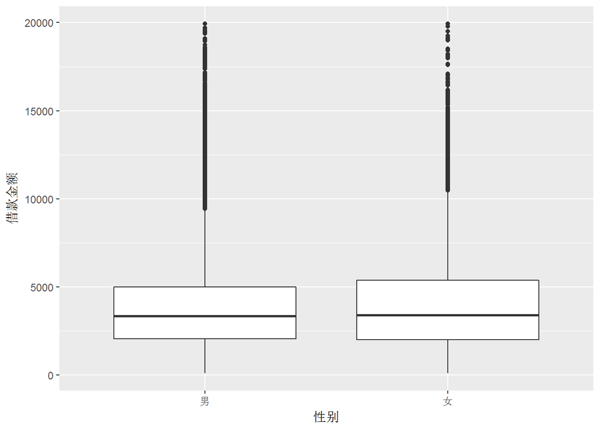

```
## lc$性别: 男
##    Min. 1st Qu.  Median    Mean 3rd Qu.    Max.
##     100    2050    3383    4512    5111  500000
## --------------------------------------------------------
## lc$性别: 女
##    Min. 1st Qu.  Median    Mean 3rd Qu.    Max.
##     100    2000    3412    4241    5466  500000
```

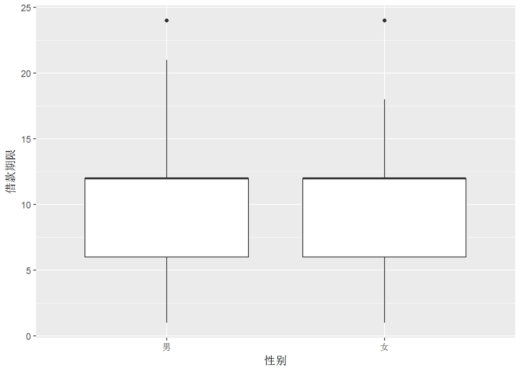

```
## lc$性别: 男
##    Min. 1st Qu.  Median    Mean 3rd Qu.    Max.
##    1.00    6.00   12.00   10.31   12.00   24.00
## --------------------------------------------------------
## lc$性别: 女
##    Min. 1st Qu.  Median    Mean 3rd Qu.    Max.
##    1.00    6.00   12.00   10.02   12.00   24.00
```

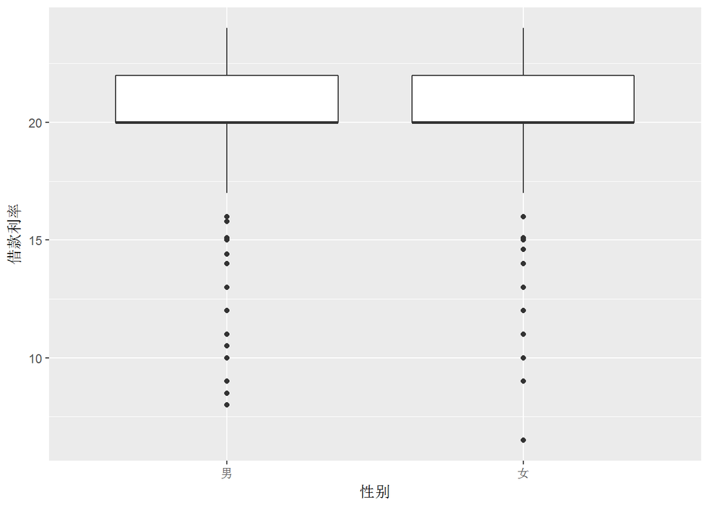

```
## lc$性别: 男
##    Min. 1st Qu.  Median    Mean 3rd Qu.    Max.
##    8.00   20.00   20.00   20.76   22.00   24.00
## --------------------------------------------------------
## lc$性别: 女
##    Min. 1st Qu.  Median    Mean 3rd Qu.    Max.
##    6.50   20.00   20.00   20.26   22.00   24.00
```

从以上三幅图中可以看出，不同性别的用户在选择借款金额、期限及利率上，几乎没什么区别。

## 双变量分析

### 主要特性与其他特性之间的关系：

在本节中，我们主要查看了逾期比与各变量之间的关系，总结如下：  
- 对于借款期限、借款利率、年龄来说，用户集中的区间，逾期比较高； - 对于借款金额和历史成功借款金额来说，金额相对越高，逾期比就会相对越低； - 用户的初始评级越低，逾期比就会越分散，中位数也会越高； - 用户的历史成功借款次数越高，逾期比就会越低； - 用户的认证项目数量越高，逾期比就会越集中，高于0.5的用户也会越少。

### 其他特性之间的关系：

- 借款期限低于5个月时的借款利率相对较高；借款期限在5-12个月之间时，借款利率相对较低；
- 不同性别的用户在年龄、借款金额、期限及利率上，几乎没什么区别。

### 你发现最强的关系是什么？

并没有发现强相关性的变量。

## 多变量绘图选择

### 借款金额-初始评级与逾期比之间的关系

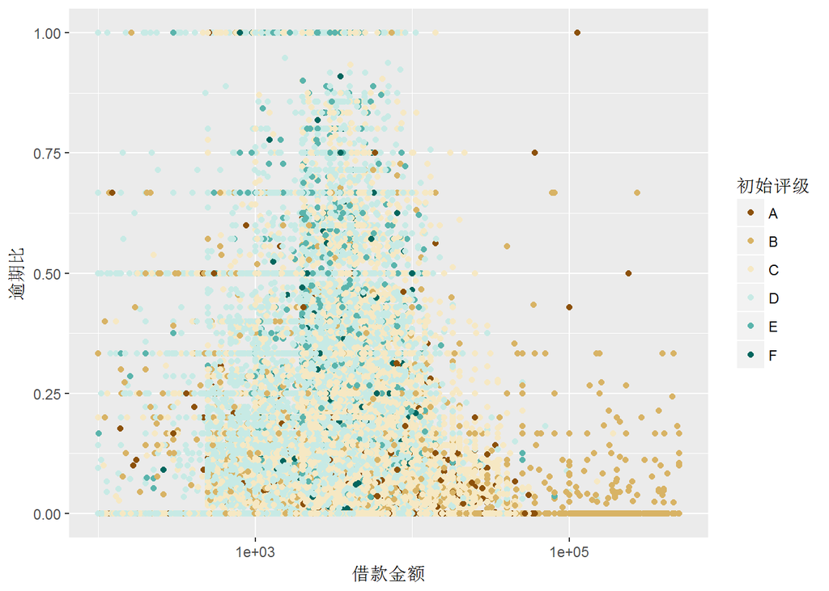

从上图中可以看出，初始评级较高的用户主要集中在图示中的右下角，他们的借款金额较高，逾期比较低；而初始评级较低的用户主要集中在图示的中央位置，借款金额较低且集中，逾期比也较高。

### 历史成功借款次数-历史成功借款金额与逾期比之间的关系

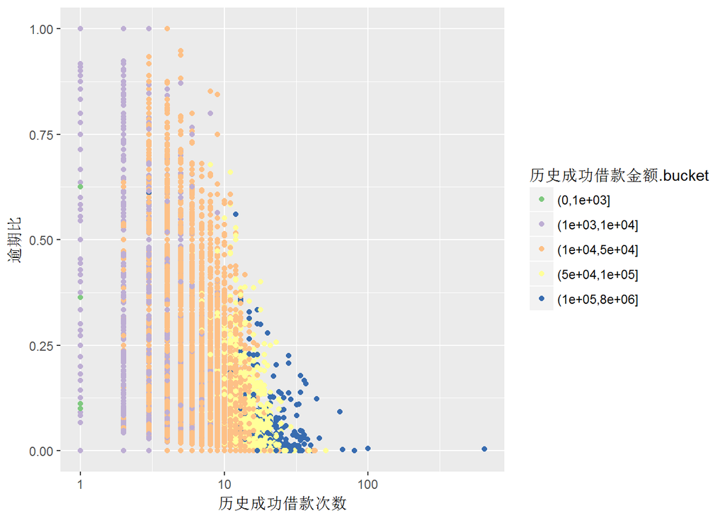

从上图中可以看出，历史成功借款金额较高的用户借款次数也较多，逾期比较低；而历史成功借款金额较低的用户借款次数较少，且逾期比较高。

### 借款金额-认证情况与逾期比之间的关系

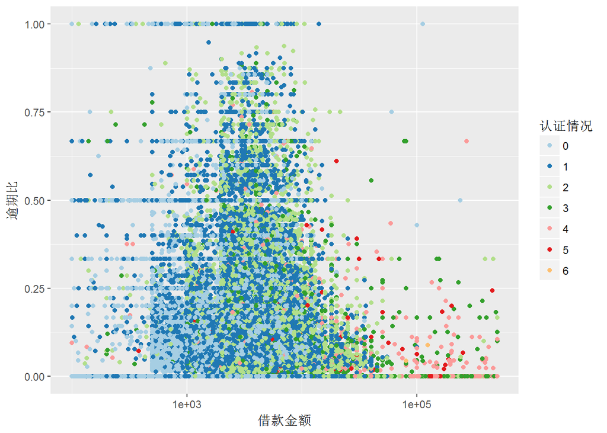

从上图中可以看出，认证数量较多的用户，在图中的位置偏右偏下，他们的借款金额更高，逾期比更低；而认证数量较少的用户，在图中的位置偏左偏上，他们的借款金额相对较低，逾期比也相对较高。

### 历史成功借款次数-历史成功借款金额-认证情况与逾期比之间的关系

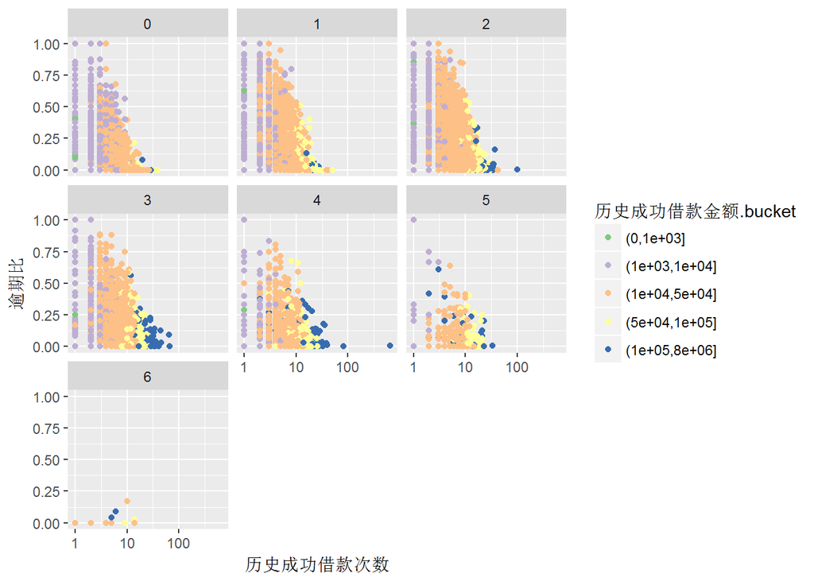

从上图中可以看出，随着认证数量的增加，历史成功借款金额较低的用户逐渐减少，金额较高的用户逐渐增多，整体的逾期比也逐渐降低。

### 借款期限-借款金额与借款利率之间的关系

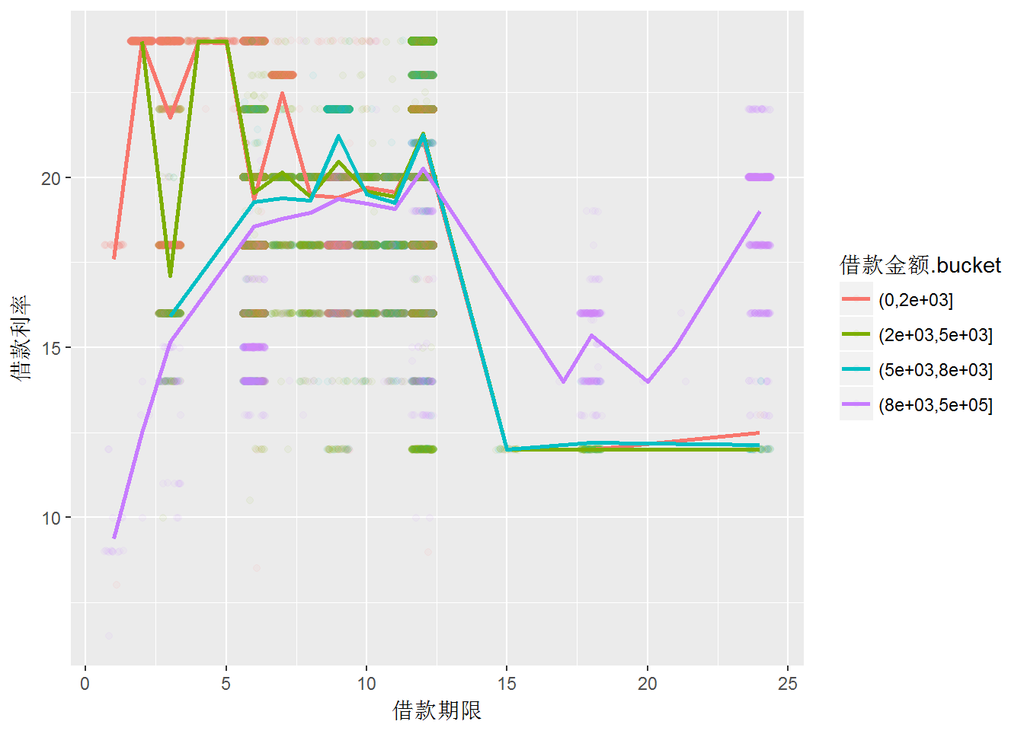

## 多变量分析

### 探讨你在这部分探究中观察到的一些关系。通过观察感兴趣的特性，是否存在相互促进的特性？

对于主要观察变量“逾期比”来说，用户的认证项目数量越多、初始评级越高、历史成功借款金额越高、历史成功借款次数越多，那么出现逾期的比例就会越小。

### 选项：你是否创建过数据集的任何模型？讨论你模型的优缺点。

因为主要观察变量“逾期比”与其他变量的相关性都很低，而且类别变量较多，所以并没有创建数据集模型。

# 定稿图与总结

### 绘图一

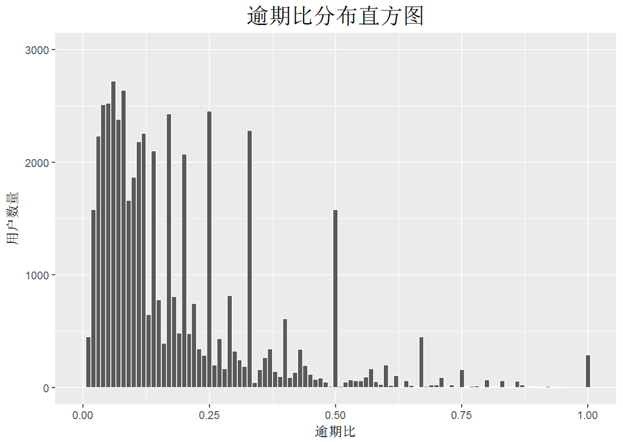

### 描述一

从上图中可以看出，大部分人的逾期比在0.25以下，但是在0.33,0.5,0.67和1处均出现了尖峰值，这说明具有高逾期比的用户数量并不少，而这些用户才是我们应该着重去关注的。

### 绘图二

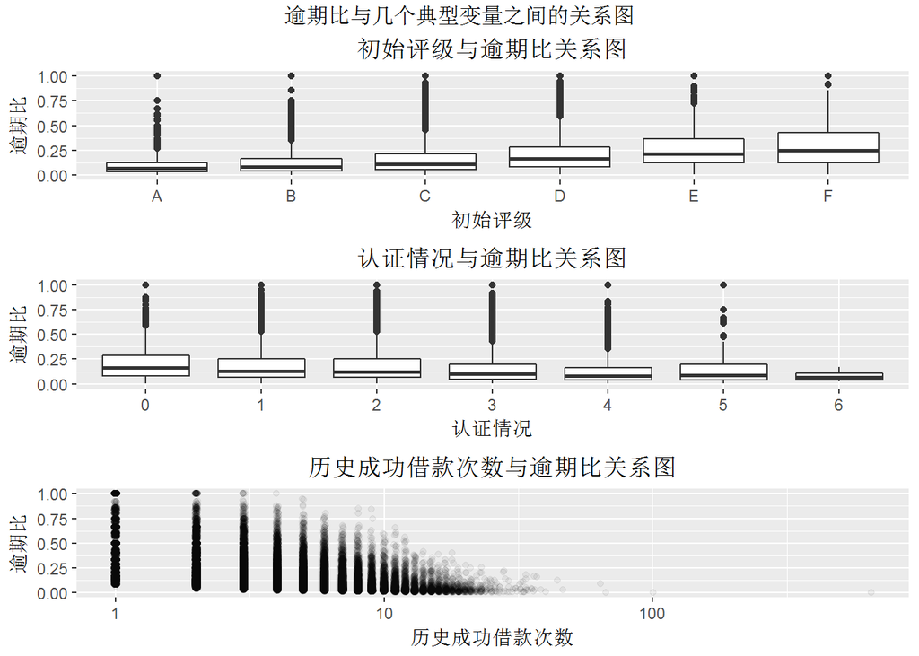

### 描述二

从上图中可以看出：

- 随着用户评级越来越低（A至F），逾期比越来越分散，中位数也越来越高；具有0.75以上逾期比的用户主要集中在C和D评分；
- 用户认证的项目数量越多，逾期比越集中，逾期比高于0.5的用户也越来越少；
- 历史成功借款次数越多，逾期比也就相对越低。

### 绘图三

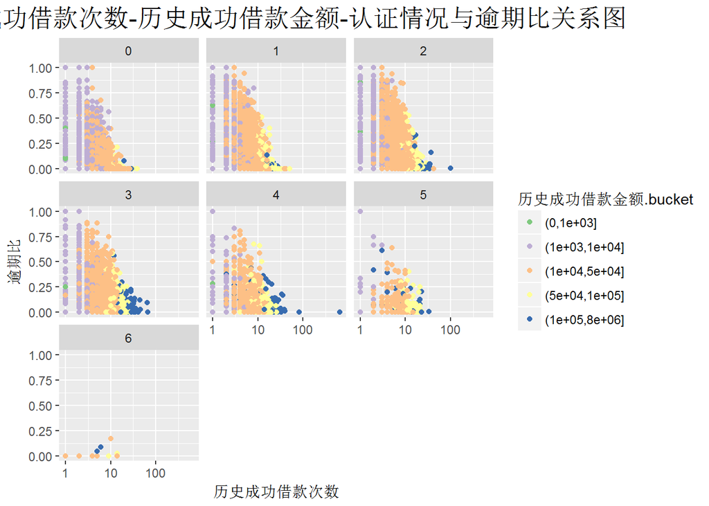

### 描述三

从上图中可以看出：随着认证数量的增加，历史成功借款金额较低的用户逐渐减少，金额较高的用户逐渐增多，整体的逾期比也逐渐降低；历史成功借款次数越高，历史成功借款金额也就越高，逾期比就会越低。

## 反思

### 项目结论

经过如上分析，我们在对借贷用户的筛选上有了决策：

- 对于认证项目较多的用户，可以适当提高借款额度，降低利息；
- 对于初始评级较高的用户，可以适当提高借款额度，降低利息；
- 对于历史借款次数较多、借款金额较高的老用户，可以适当提高借款额度，降低利息或发放免息抵扣券；
- 对于认证项目少于或等于2项，初始评级低于或等于C级的用户，可以适当降低借款额度，提高利息；
- 对于新注册用户，多鼓励其进行身份认证，并适当降低利息或发放免息抵扣券，鼓励其借款。

### 不足

- 未对项目进行建模，研究不够深入，不能实现期望的“逾期比预测”功能；
- 对于数据来说，并不能获取用户的月收入等信息，也是影响分析结果丰富性的原因之一。

### 对未来工作的提议

- 把复杂的数据整理交给python完成，在R中重点关注分析及可视化；
- 先找出数据集中的关键变量，然后再按照单变量分析-双变量分析-多变量分析的步骤去抽丝拨茧，找出关键变量与其他特征之间的关系；
- 不要为了可视化而可视化，要带着问题去做可视化。
- 不仅要考虑结果分析的正确性，还要丰富文字描述以及可视化结果的展示，提高报告的阅读性。

### 分析中所做的重要决定

- 最重要的决定莫过于“逾期比”这个变量的创建，这决定了整篇报告的分析重点；
- 其次是“认证情况”变量的创建，因为原数据集中有六项不同的身份认证情况，分析起来比较麻烦，而且这几个变量主次性不明显，说明的也都是一类问题，所以把他们整合起来是最合适的选择，化繁为简，找出了认证项目数量与逾期比之间的关系。